# Foundations for statistical inference - Confidence intervals

> “How big is the typical house in Ames?”

> “How much variation is there in sizes of houses?”.

If you have access to *data on an entire population*, the size of every house in Ames, Iowa, straightforward to answer

If you have access to only *a sample of the population*, the task becomes more complicated.

What is your best guess for the typical size if you only know the sizes of several dozen houses?

This type of situation requires that you **use your sample to make inference on what your population looks like**.

## Getting Started

### Load packages

In this lab, we will explore and visualize the data using the **tidyverse** suite of packages, and perform statistical inference using **infer**.

Let's load the packages.

```r
library(tidyverse)
library(infer)

set.seed(20200518)
```

### The data

- Population of interest: residential home sales in Ames between 2006 and 2010.
- In this lab, learn about these home sales by taking smaller samples from the full population.

Let’s load the data.

```r
ames <- read.csv("data/ames.csv") %>%
        rename(area=Gr.Liv.Area) # rename Gr.Liv.Area as area, which is the variable of  our main interest
```

- Start with a simple random sample of size 60 from the population using the `rep_sample_n` function from the `infer` package.

```r
n <- 60

# taking one sample of size 60 without replacement.
samp <- ames %>%
    rep_sample_n(size=n)
```

**Recall** : if you want to learn more about the arguments of a function, *typing ? in front of the function* to pull up the help page.

**Note** `ames` has information on many housing variables, but we focus on the size of the house, represented by the variable `area`

#### **Problem 1 :**

Describe the distribution of house area in your sample. What would you say the typical size in your sample?

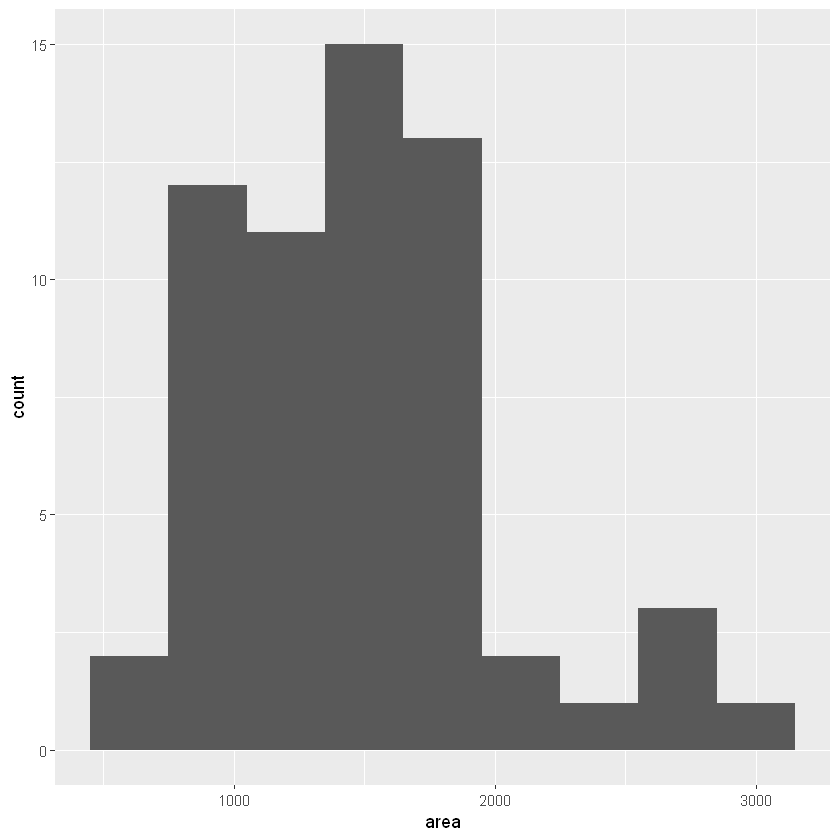

```r
ggplot(samp, aes(x=area))+
geom_histogram(binwidth=300)
```

```r
samp %>%
    summarize(s_mean=mean(area, na.rm=T),
              s_median=median(area, na.rm=T))
```

A tibble: 1 × 3

| replicate <int> | s_mean <dbl> | s_median <dbl> |
| --- | --- | --- |
| 1 | 1491.267 | 1471 |

**Answer**: The distribution of `area` is approximately unimodal and a bit right skewed. The sample median is a reasonable meansure as a typical size of house since the distribution is right skewed. The sample median of house area in Ames is about 1471.

## Confidence intervals

> Based on this sample, what can you infer about the population?

**sample mean**

- denoted as $\overline{x}$
- the best **point estimate** of the population mean

**confidence interval**

- quantify the uncertainty : **how uncertain** the point estimate is .
- calculation of a confidence interval for a population mean
  - based on the **Central Limit Theorem** $$ \overline{x} \pm z^* SE_{\overline{x}} $$ more precisely $$ \overline{x} \pm z^*\frac{s}{\sqrt{n}} $$

### 95 percent confidence interval for the average living area of houses sold in Ames.

- Calculate the sample mean, and use this to calculate and store the lower and upper bounds of the confidence interval.

**Note**: `qnorm` is set to 0.975 for a two-sided 95 percent confidence interval since the upper bound is at the 97.5 percentile.

```r
samp %>%
    summarise(x_bar=mean(area),
             se=sd(area)/sqrt(n),
             me=qnorm(0.975)*se,
             lower=x_bar-me,
             upper=x_bar+me)
```

A tibble: 1 × 6

| replicate <int> | x_bar <dbl> | se <dbl> | me <dbl> | lower <dbl> | upper <dbl> |
| --- | --- | --- | --- | --- | --- |
| 1 | 1491.267 | 69.18205 | 135.5943 | 1355.672 | 1626.861 |

Even though we don’t know what the full population looks like, we’re 95% confident that the true average size of houses in Ames lies between the two printed values.

## Confidence levels

#### **Problem 2 :**

In the interpretation above, we used the phrase "95% confident". What does "95% confidence" mean?

**Answer** If you took many samples and built a confidence interval from each sample using the equation *point estimate* $\pm 2\times$ *SE* or percentiles of the bootstrap distribution of the sample mean, about 95% of those intervals would contain the true population mean.

In this case, we have the rare luxury of knowing the true population mean since we suppose to have data on the entire population.

- calculate the population mean

  > we can determine if our confidence intervals actually capture it.
- store it in a data frame called `params` (short for population parameters), and name it `mu`.

```r
params <- ames %>%
    summarise(mu=mean(area))
params
```

A data.frame: 1 × 1

| mu <dbl> |
| --- |
| 1499.69 |

#### **Problem 3 :**

Does the confidence interval capture the true average size of houses in Ames?

In the next part of the lab, you will collect many samples to learn more about how sample means and confidence intervals constructed based on those samples vary from one sample to another.

- Obtain a random sample.
- Calculate the sample mean, and use this to calculate and store the lower and upper bounds of the confidence intervals.
- Repeat these steps 50 times.

```r
ci <- ames %>%
    rep_sample_n(size=n, reps=50) %>%
    summarise(x_bar=mean(area),
             se=sd(area)/sqrt(n),
             me=qnorm(0.975)*se,
             lower=x_bar-me,
             upper=x_bar+me)
```

Let’s view the first five intervals:

```r
ci %>% slice(1:5)
```

A tibble: 5 × 6

| replicate <int> | x_bar <dbl> | se <dbl> | me <dbl> | lower <dbl> | upper <dbl> |
| --- | --- | --- | --- | --- | --- |
| 1 | 1452.583 | 69.03330 | 135.3028 | 1317.281 | 1587.886 |
| 2 | 1461.200 | 66.92345 | 131.1675 | 1330.032 | 1592.368 |
| 3 | 1465.067 | 69.08095 | 135.3962 | 1329.670 | 1600.463 |
| 4 | 1519.983 | 70.55301 | 138.2814 | 1381.702 | 1658.265 |
| 5 | 1458.167 | 59.22093 | 116.0709 | 1342.096 | 1574.238 |

#### Figure of confidence intervals on page 7 of lecture slide 3.5 Confidence Intervals

- create a new variable in the ci data frame that indicates whether the interval does or does not capture the true population mean.

```r
ci <- ci %>%
    mutate(capture_mu=ifelse(lower<params$mu & upper>params$mu, "yes","no"))
```

- convert `ci` to `ci_data` data frame by using `gather` function
- plot 50 CIs.

A tibble: 6 × 7

| replicate <int> | x_bar <dbl> | se <dbl> | me <dbl> | capture_mu <chr> | type <chr> | bound <dbl> |
| --- | --- | --- | --- | --- | --- | --- |
| 1 | 1452.583 | 69.03330 | 135.3028 | yes | lower | 1317.281 |
| 2 | 1461.200 | 66.92345 | 131.1675 | yes | lower | 1330.032 |
| 3 | 1465.067 | 69.08095 | 135.3962 | yes | lower | 1329.670 |
| 4 | 1519.983 | 70.55301 | 138.2814 | yes | lower | 1381.702 |
| 5 | 1458.167 | 59.22093 | 116.0709 | yes | lower | 1342.096 |
| 6 | 1476.400 | 60.50929 | 118.5960 | yes | lower | 1357.804 |

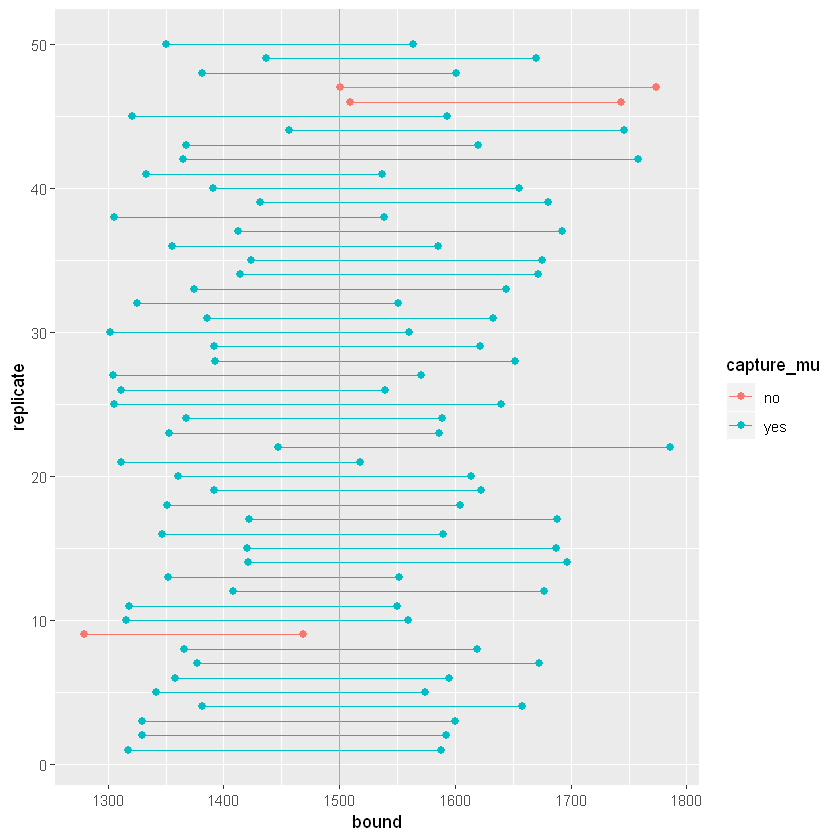

```r
ci_data <- gather(ci, type, bound, lower:upper)
head(ci_data)

ggplot(data=ci_data, aes(x=bound, y=replicate, group=replicate, color=capture_mu))+
    geom_point(size=2)+
    geom_line()+
    geom_vline(xintercept=params$mu, color="darkgray")
```